# Assignment 8-1 Maximum Likelihood Lab

Feng-Hsun Chang

2016 Nov. 15

# Exercise 1

- What does the shape of the likelihood surface tell us about the identifiability of the parameters? What does it say about which aspects of the data are most informative?

This shape indicates that on a certain axis of parameter “a” and “b” combination, the likelihood of observing this given data are similar. Along this combination axis, the data are not informative to tell if the model is good enough to describe (or explain?) the data.

Here I add a line indicating the carapace length at which the probability of seropositive is 50% given the estimated parameter “a” and “b”.

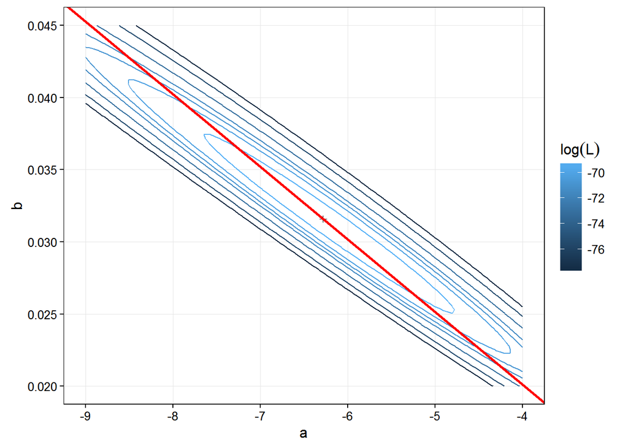

```r
gt = read.csv("http://kinglab.eeb.lsa.umich.edu/480/data/gophertortoise.csv",
              comment.char="#",colClasses=c(date="Date",sex="factor",elisa="factor")) %>%
     arrange(carapace.length,date)
gt1 = gt %>%
  ddply(~id,subset,date==min(date)) %>%
  mutate(serostatus=ifelse(elisa=="neg",0,1))

loglik = function (p, serostatus) {
  sum(log(dbinom(x=serostatus,size=1,prob=p)))
}

nll = function (a, b, carapace.length, serostatus) {
  -loglik(p=plogis(a+b*carapace.length),serostatus)
}

fit = mle2(nll,start=list(a=0,b=0),data=gt1)

params =
  expand.grid(
  a=seq(-9,-4,length=100),
  b=seq(0.02,0.045,length=100)) %>%
  ddply(~a+b,mutate,
        loglik=-nll(a,b,gt1$carapace.length,gt1$serostatus)
  )

breaks <- logLik(fit)-qchisq(p=c(0.5,0.8,0.9,0.95,0.99,0.999,0.9999),df=2)/2

ggplot(data=params, aes(x=a,y=b,z=loglik))+
  stat_contour(aes(color=..level..),breaks=breaks)+
  geom_point(x=coef(fit)["a"],y=coef(fit)["b"],shape=3)+
  labs(color=expression(log(L)))+
  geom_abline(slope=(coef(fit)["b"]/coef(fit)["a"]), intercept=0, col="red", size=1)+
  theme_bw()+
  theme(#panel.grid.major=element_blank(),
        panel.grid.minor=element_blank(),
        strip.background = element_blank(),
        panel.border=element_rect(color="black"),
        legend.key = element_blank())
```

We see that along this axis, the data is rather not informative.  
I now try another model to describe the data with another model that intends to describe how much the probability of seropositive would change when an individual grows larger (or is smaller) than a certain carapace length. This carapace length is the length where the probability of seropositive is 50% given the estimated parameter “a (-6.2817)” and “b (0.0316)” in the previous model. So the odds ration function becomes the following.

$$\mathrm{logit}(p_i) = p_0 + p_1(L_i-198.844)$$
,

where $p_0$ is the probability of seropositive when the carapace length is at 198.844, and $p_1$ is the change of seropositive probability when the individual grows larger (or is smaller) then 198.844.

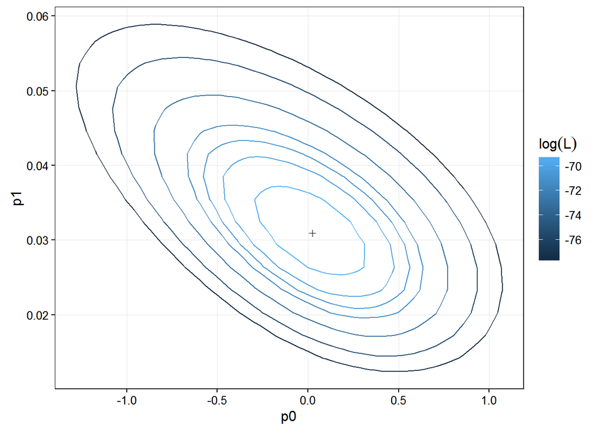

```r
L50 = -(coef(fit)["a"]/coef(fit)["b"])

loglik = function (p, serostatus) {
  sum(log(dbinom(x=serostatus,size=1,prob=p)))
}

nll.1 = function (p0, p1, carapace.length, serostatus) {
  -loglik(p=plogis(p0+p1*(carapace.length-L50)), serostatus)
}

fit.1 = mle2(nll.1, start=list(p0=0,p1=0),data=gt1)

params.1 =
  expand.grid(
  p0=seq(coef(fit.1)["p0"]-1.5, coef(fit.1)["p0"]+1.5, length=100),
  p1=seq(coef(fit.1)["p1"]-0.15, coef(fit.1)["p1"]+0.15, length=100)) %>%
  ddply(~p0+p1, mutate,
        loglik=-nll.1(p0, p1, gt1$carapace.length, gt1$serostatus)
  )

breaks.1 = logLik(fit.1)-qchisq(p=c(0.5,0.8,0.9,0.95,0.99,0.999,0.9999),df=2)/2

ggplot(data=params.1, aes(x=p0, y=p1, z=loglik))+
  geom_contour(aes(color=..level..), breaks=breaks.1)+
  geom_point(x=coef(fit.1)["p0"], y=coef(fit.1)["p1"], shape=3)+
  labs(color=expression(log(L)))+
  theme_bw()+
  theme(#panel.grid.major=element_blank(),
        panel.grid.minor=element_blank(),
        strip.background = element_blank(),
        panel.border=element_rect(color="black"),
        legend.key = element_blank())
```

We see that the likelihood surface is different from the previous one. In this model, the two parameters looks more informative than the previous two (“a” and “b”) as the surface becomes more rounded. This indicates that the changes in either p0 and p1 parameters would lead to large decrease in likelihood. This model is also easier to interpret. The “p0” parameter means the probability of seropositive when the carapace is at 198.844. The “p1” parameter means the rate of increase when an individual grow larger than 198.844 in exponential scale. For example, with 1 mm increase in carapace length, the probability of seropositive would increase 1.031%.

# Exercise 2

- Use `mle2` to fit the survival curve, assuming a constant force of infection and that $L \propto a$. Estimate the force of infection. What are its units? Use confidence intervals (CI) to quantify the uncertainty in your estimate. Make a plot that overlays the model predictions on the data. Plot the likelihood curve. Indicate the MLE and CI for different levels on your plot.

Here I’m using the following exponential function to model the decline of seronegative probability.

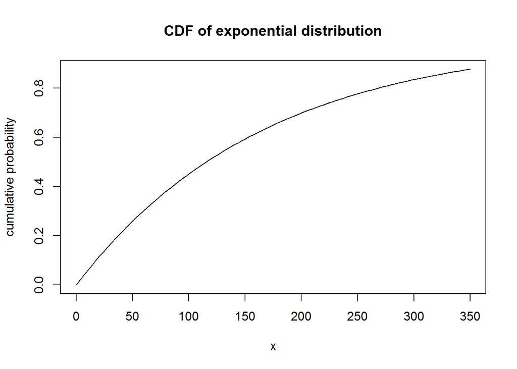

```r
curve(pexp(x, rate=0.006),from=0,to=350, ylab="cumulative probability", main="CDF of exponential distribution")
```

Now I estimate the $\lambda$ parameter that determines the probability of seropositive and the maximum likelihood associated with the estimated $\lambda$.

```r
loglik = function (p, serostatus) {
  sum(log(dbinom(x=serostatus,size=1,prob=p)))
}

nll.2 = function (lam, carapace.length, serostatus) {
  -loglik(p=pexp(carapace.length, rate=lam), serostatus)
}

fit.2 = mle2(nll.2, start=list(lam=0.01),data=gt1)

coef(fit.2)
```

```
##         lam
## 0.005646204
```

```r
logLik(fit.2)
```

```
## 'log Lik.' -82.60993 (df=1)
```

- Note that I mute the warning here as I know some negative $\lambda$ would produce probabilities that generate NaN when being used to calculate likelihood.

The $\lambda$ is estimated to be 0.0056462 and the associated maximum likelihood is -82.6099312.  
I then calculate the confidence interval of the $\lambda$ parameter.

```
##       2.5 %      97.5 %
## 0.004590974 0.006879808
```

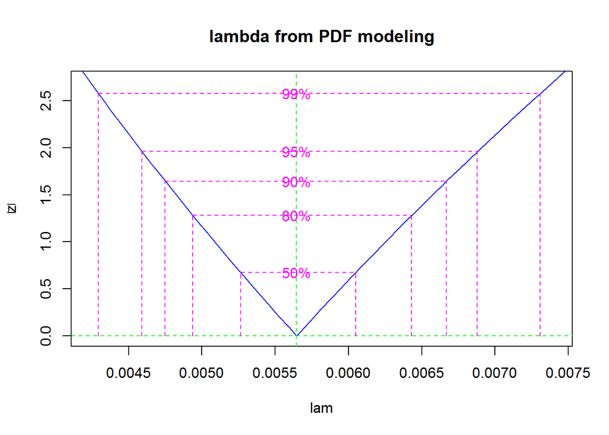

I then overlay the model predictions on the data.

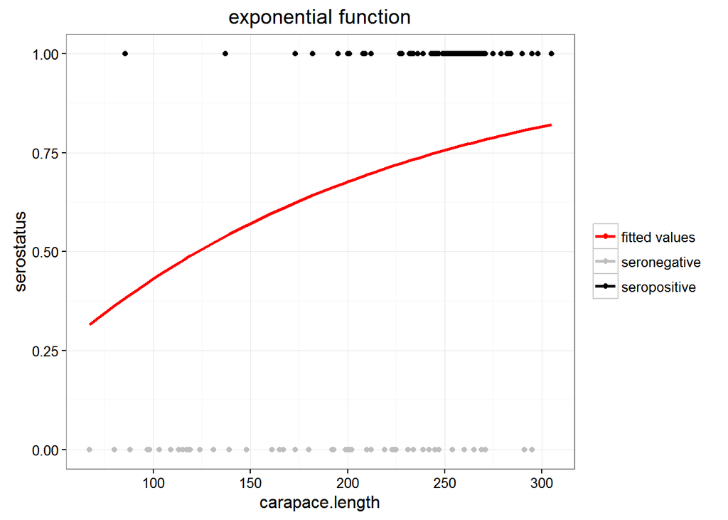

```r
gt1 =
  gt1 %>% mutate(
    fitted.exp=with(as.list(coef(fit.2)),pexp(carapace.length, rate=lam)))

gt1 %>%
  ggplot(aes(x=carapace.length))+
  geom_point(aes(y=serostatus, color=elisa))+
  geom_line(aes(y=fitted.exp, color="fitted"), size=1)+
  scale_color_manual(name="",
                     values=c(fitted="red", neg="grey", pos="black"),
                     labels=c(fitted="fitted values", neg="seronegative", pos="seropositive"))+
  ggtitle("exponential function")
```

From this plot we see that the fitted probability of seropositive increases with carapace length. The increasing rate, $\lambda$, is estimated to be 0.0056462. The $\lambda$ is the exponential decreasing rate of the probability of seronegative. The unit of $\lambda$ is $mm^{-1}$.

# Exercise 3

- Investigate a two-parameter model in which the hazard increases with age.

Here I made the exponential decreasing rate of seronegative probability, $\lambda$, as Michaelis-Menten function. The hazard thus increase with carapace length. This michaelis-menten function is determined by two parameters, “rm” that determines the maximum exponential decreasing rate and “Kr” that determines the carapace length that renders half of the maximum decreasing rate.

```r
loglik = function (p, serostatus) {
  sum(log(dbinom(x=serostatus,size=1,prob=p)))
}

nll.4 = function (rm, Kr, carapace.length, serostatus) {
  -loglik(p=pexp(carapace.length, rate=rm*(carapace.length/(Kr+carapace.length))), serostatus)
}

fit.4 = mle2(nll.4, start=list(rm=0.1, Kr=50),data=gt1)

coef(fit.4)
```

```
##           rm           Kr
##  0.007040965 50.048034928
```

```r
logLik(fit.4)
```

```
## 'log Lik.' -80.13321 (df=2)
```

- Note that, similar to previous model (the model with constant hazard), there are some negative $\lambda$ would produce probabilities that generate NaN when being used to calculate likelihood.

The estimated maximum decreasing rate of the probability of seropositive (“rm”) is 0.007 and the carapace length that would render half of the maximum decreasing rate is about 50.048mm. The associated maximum likelihood is -80.133207. However, I found this model not intuitive to interpret, since the model describes the change of exponential decreasing rate not the probability per se.

I now construct the likelihood contour.

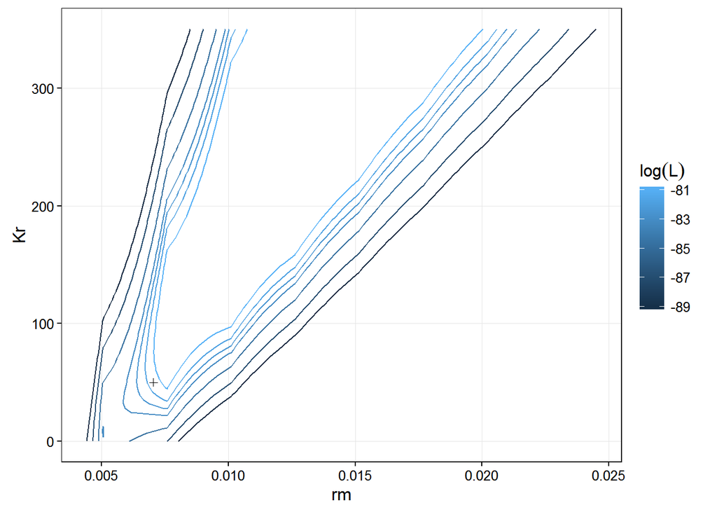

```r
params.4 =
  expand.grid(
  rm=seq(0, 0.25, length=100),
  Kr=seq(0, 350, length=100)) %>%
  ddply(~rm+Kr, mutate,
        loglik=-nll.4(rm, Kr, gt1$carapace.length, gt1$serostatus)
  )

breaks.4 = logLik(fit.4)-qchisq(p=c(0.5,0.8,0.9,0.95,0.99,0.999,0.9999),df=2)/2

ggplot(data=params.4, aes(x=rm, y=Kr, z=loglik))+
  geom_contour(aes(color=..level..), breaks=breaks.4)+
  geom_point(x=coef(fit.4)["rm"], y=coef(fit.4)["Kr"], shape=3)+
  labs(color=expression(log(L)))+
  theme_bw()+
  theme(#panel.grid.major=element_blank(),
        panel.grid.minor=element_blank(),
        strip.background = element_blank(),
        panel.border=element_rect(color="black"),
        legend.key = element_blank())
```

I found that this contour is wired as the estimated value is not at the central of the contour…In addition, the two parameters here are not informative to judge the model.

Here I overlay the fitted seropositive probability to the data.

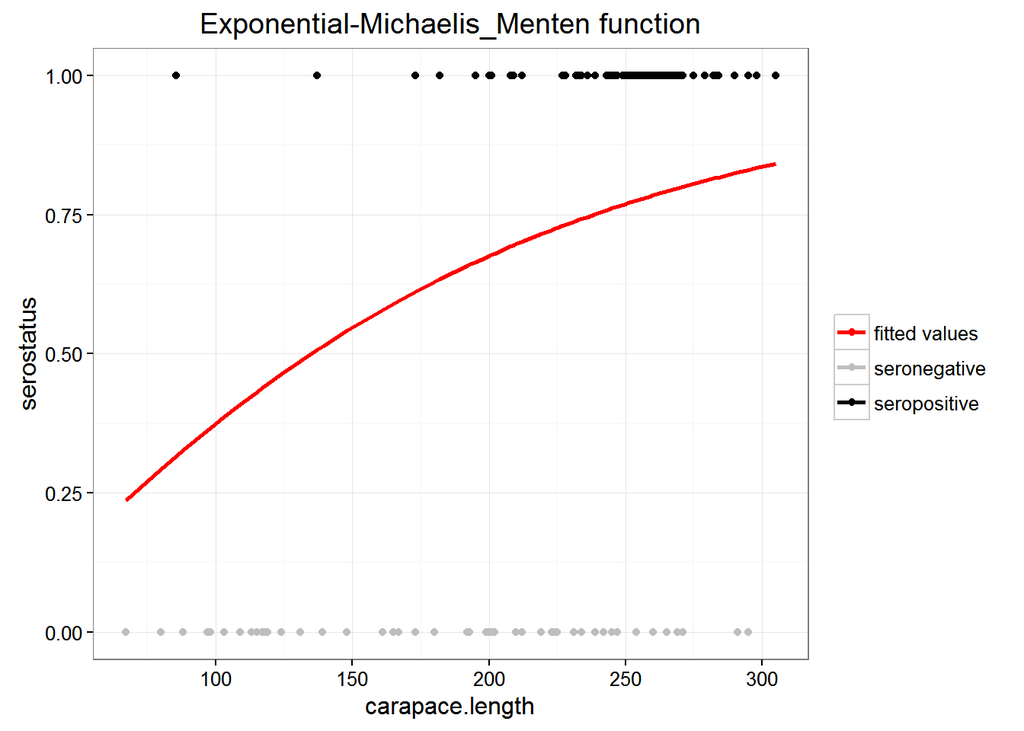

```r
gt1 =
  gt1 %>% mutate(
    fitted.MM1=with(as.list(coef(fit.4)),pexp(carapace.length, rate=rm*(carapace.length/(Kr+carapace.length)))))

gt1 %>%
  ggplot(aes(x=carapace.length))+
  geom_point(aes(y=serostatus, color=elisa))+
  geom_line(aes(y=fitted.MM1, color="fitted"), size=1)+
  scale_color_manual(name="",
                     values=c(fitted="red", neg="grey", pos="black"),
                     labels=c(fitted="fitted values", neg="seronegative", pos="seropositive"))+
  ggtitle("Exponential-Michaelis_Menten function")
```

The above model is rather not strait forward to me. I therefore tried the following model that is also determined by two parameters and a Michaelis-Menten function. The Michaelis-Menten function used here is to determine the probability of seropositive directly, but not the rate of exponential decreasing rate of the exponential function.

Here I use Michaelis-Menten function to generate a probability of seropositive and then used the generated probability to calculate the associated likelihood. I then use the `optim` function to find the two parameters in the Michaelis-Menten function that lead to the maximum likelihood. These two parameters are the maximum probability (“p.max”) and the carapace length that renders 50% of possibility of seropositive (“K”).

Note that I constrain the “p.max” to be from 0 to 1. Otherwise it is not biologically feasible.

```r
loglik = function (p, serostatus) {
  sum(log(dbinom(x=serostatus,size=1,prob=p)))
}

nll.3 = function (data, par) {
  with(data, -loglik(p=par[1]*(data[,"carapace.length"]/(par[2]+data[,"carapace.length"])), data[,"serostatus"]))
}

fit.3 = optim(par=c(0.1, 50), nll.3, method="L-BFGS-B", lower=c(0,0), upper=c(1,max(gt1[,"carapace.length"])), data=gt1, hessian=TRUE)

p.max=fit.3$par[1]
K=fit.3$par[2]
ML=-fit.3$value
```

The max probability of seropositive is 1 and the carapace length that would render 50% of possibility of seropositive is about 97.535mm. The associated maximum likelihood is -88.0226788. It is not surprising that the “p.max” parameter is 1. However, I found it intriguing that the carapace length that renders 50% of probability of seropositive is about half of that in the first model (198.843991). This suggests to me that the fundamental differences between the model can results in different estimates, although the biological interpretations are similar.

Now I construct the likelihood surface of the two parameters.

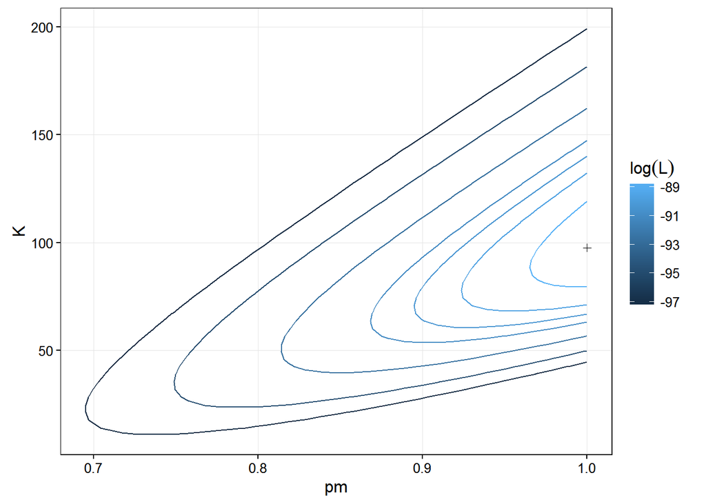

```r
params.3 =
  expand.grid(
  pm=seq(0, 1, length=100),
  K=seq(0, 350, length=100)) %>%
  ddply(~pm+K, mutate,
        loglik=-nll.3(data=gt1, par=c(pm, K))
  )

breaks.3 <- -fit.3$value-qchisq(p=c(0.5,0.8,0.9,0.95,0.99,0.999,0.9999),df=2)/2

ggplot(data=params.3, aes(x=pm, y=K, z=loglik))+
  geom_contour(aes(color=..level..), breaks=breaks.3)+
  geom_point(x=fit.3$par[1], y=fit.3$par[2], shape=3)+
  labs(color=expression(log(L)))+
  theme_bw()+
  theme(#panel.grid.major=element_blank(),
        panel.grid.minor=element_blank(),
        strip.background = element_blank(),
        panel.border=element_rect(color="black"),
        legend.key = element_blank())
```

Question : I can’t figure out how to manually calculate the confidence interval of the parameters estimated by the `optim` function. I guess I don’t fully understand how to back calculate the parameter values that renders certain likelihood value.

Now I overlay the fitted probability onto the data.

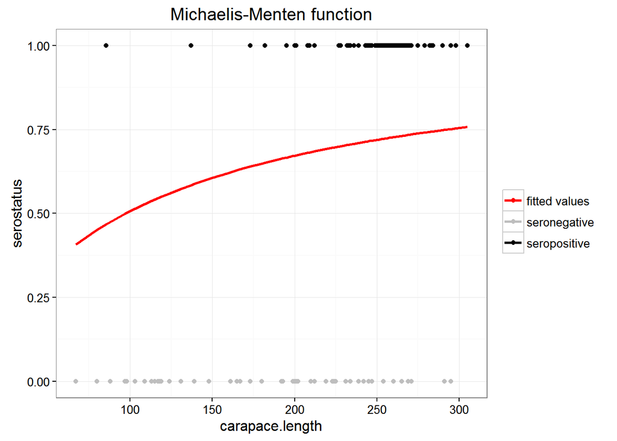

```r
gt1 =
  gt1 %>% mutate(
    fitted.MM=fit.3$par[1]*(gt1[,"carapace.length"]/(fit.3$par[2]+gt1[,"carapace.length"])))

gt1 %>%
  ggplot(aes(x=carapace.length))+
  geom_point(aes(y=serostatus, color=elisa))+
  geom_line(aes(y=fitted.MM, color="fitted"), size=1)+
  scale_color_manual(name="",
                     values=c(fitted="red", neg="grey", pos="black"),
                     labels=c(fitted="fitted values", neg="seronegative", pos="seropositive"))+
  ggtitle("Michaelis-Menten function")
```

The fitted probability of this model is the one with lowest predicted seropositive probability when at maximum carapace length in the data and the highest predicted seropositive probability when at minimum carapace length in the data.

# Exercise 4

So far, I have fitted 5 models with different link functions ($p_i$ is the probability of seropositive) to the data .
1.Generic logistic function.
$$\mathrm{logit}(p_i) = a + bL_i$$

2.modified logistic function.
$$\mathrm{logit}(p_i) = p_0 + p_1(L_i-198.844)$$
, where $p_0$ is the probability of seropositive when the carapace length is at 198.844, and $p_1$ is the change of seropositive probability when the individual grows larger (or is smaller) then 198.844.

5.seropostive probability increase with a Mechaelis-Menten function of carapace length
$$p_i = pm(\frac{L_i}{K+L_i})$$
, where $pm$ determines the maximum probability of seropositive and $K$ determines the carapace length that renders half of the maximum seropositive probability.

Now I campare the AIC value of these 5 models, since none of these models are nested.  
Question : Not sure if Model 4 is nested in Model 3. I’m not entirely clear about how to judge if two models are nested.

```r
AICtable=data.frame()

for (i in 1:5){
  AICtable[i,1] = paste0("Model", i)
}

AICtable[1,2] = round(AIC(fit),3)
AICtable[2,2] = round(AIC(fit.1),3)
AICtable[3,2] = round(AIC(fit.2),3)
AICtable[4,2] = round(AIC(fit.4),3)
AICtable[5,2] = round(2*fit.3$value+2*length(fit.3$par),3)
  colnames(AICtable)=c("Model", "AIC value")

kable(AICtable)
```

| Model | AIC value |
| --- | --- |
| Model1 | 140.875 |
| Model2 | 140.858 |
| Model3 | 167.220 |
| Model4 | 164.266 |
| Model5 | 180.045 |

From the above table, I see that model 1 and 2 (the generic logistic link function) performs the best from the five. However, Model 2 (modified logistic link function) would be the better than Model 1 as the parameters are more informative and easier to interpret. The other three models are not comparable probably due to the fact that there is an inflection point in the increasing pattern of seropositive probability. The logistic function is the only function that captures this inflection point. This makes me wonder if there is another link function that also have this kind of feature.